# Lu,STAT479_midterm

```python
import tensorflow as tf
import keras as keras
import pandas as pd
import numpy as np
import matplotlib.pyplot as plt
import random
import seaborn as sns

from sklearn.preprocessing import StandardScaler
from sklearn.preprocessing import MinMaxScaler
from sklearn.model_selection import train_test_split

from tensorflow.keras.models import Sequential
from tensorflow.keras.layers import Dense, LeakyReLU, Dropout
from tensorflow.keras.optimizers import Adam
```

## Predicting Customer Purchase Behavior with FNN

#### Marian Lu, STAT 479 Take-home Midterm

Objective: Building, evaluating, and interpreting a Feedforward Neural Network (FNN) for classifying whether or not a customer will make a purchase based on e-commerce data.

## 1 Data Preprocessing

```python
# Reading in data
df = pd.read_csv('customer_purchase_data.csv')
```

### 1.1 Data Selection

**Predict Customer Purchase Behavior Dataset**

This dataset is provided by Kaggle and contains information on customer purchase behavior on an online shopping website. It has 1500 observations, 8 features, and 1 target variable.

**Features:**

- Age: Customer's age
- Gender: Customer's gender (0: Male, 1: Female)
- Annual Income: Annual income of the customer in dollars
- Number of Purchases: Total number of purchases made by the customer
- Product Category: Category of the purchased product (0: Electronics, 1: Clothing, 2: Home Goods, 3: Beauty, 4: Sports)
- Time Spent on Website: Time spent by the customer on the website in minutes
- Loyalty Program: Whether the customer is a member of the loyalty program (0: No, 1: Yes)
- Discounts Availed: Number of discounts availed by the customer (range: 0-5)
- PurchaseStatus (Target Variable): Likelihood of the customer making a purchase (0: No, 1: Yes)

**Target Variable**

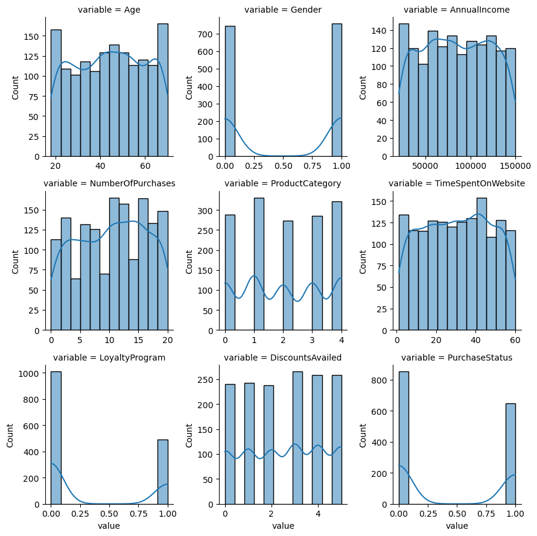

```python
# plotting distributions of all variables
g = sns.FacetGrid(df.melt(value_vars=df.columns), col='variable', col_wrap=3, sharex=False, sharey=False)
g.map(sns.histplot, 'value', kde=True)
plt.show()
```

The distributions of the numeric variables are abnormal, but we can account for this by standarization (covered later in the preprocessing section). The binary features are balanced in the case of Gender, but slightly unbalanced in the case of LoyaltyProgram. However, this shouldn't affect the model's performance drastically since the target variable, PurchaseStatus, is close to being balanced.